# Homework 6

**Question 1:** Choose a country (not the US).

Use the package maps to show a map of the country:

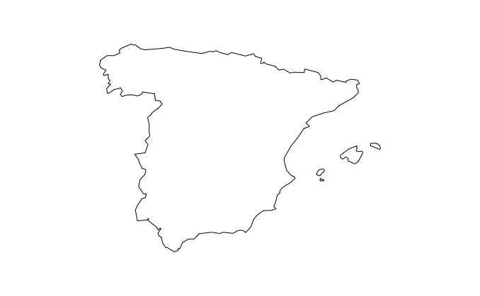

```r
library(maps)
map(database = "world", regions = "Spain", exact = FALSE, boundary = TRUE,
    interior = TRUE)
```

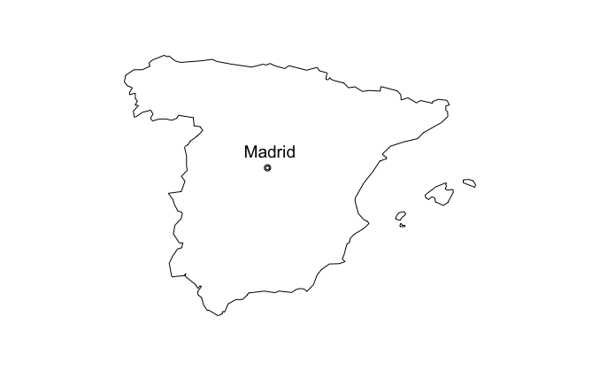

```r
map("world", "Spain")
map.cities(country = "Spain", capitals = 1)
```

The dataset `world.cities` included in the map package contain information about the location and population of several cities in the world. Create a new data frame containing only the cities in the country you chose:

```r
#newdf <- world.cities$country.etc == "Spain"
spain <- subset(world.cities, country.etc == "Spain")
spain
```

|  | name | country.etc | pop | lat | long | capital |
| --- | --- | --- | --- | --- | --- | --- |
| 128 | A Coruna | Spain | 243088 | 43.33 | -8.42 | 0 |
| 129 | A Estrada | Spain | 21997 | 42.70 | -8.50 | 0 |
| 130 | A Laracha | Spain | 10856 | 43.25 | -8.59 | 0 |
| 131 | A Pobra do Caraminal | Spain | 9955 | 42.61 | -8.94 | 0 |
| 183 | Abanto Zierbena | Spain | 9505 | 43.32 | -3.08 | 0 |
| 186 | Abaran | Spain | 12890 | 38.20 | -1.40 | 0 |
| 254 | Abrera | Spain | 9966 | 41.52 | 1.90 | 0 |
| 414 | Adra | Spain | 22900 | 36.76 | -3.02 | 0 |
| 574 | Aguilar de Campoo | Spain | 7224 | 42.80 | -4.27 | 0 |
| 575 | Aguilar de la Frontera | Spain | 13502 | 37.52 | -4.65 | 0 |

[output cut: 854 more lines]

Now take a look the cities, choose a population threshold that will lead to only about 20 cities in your dataset and plot the location of these cities in the country map using the `map.cities` function :

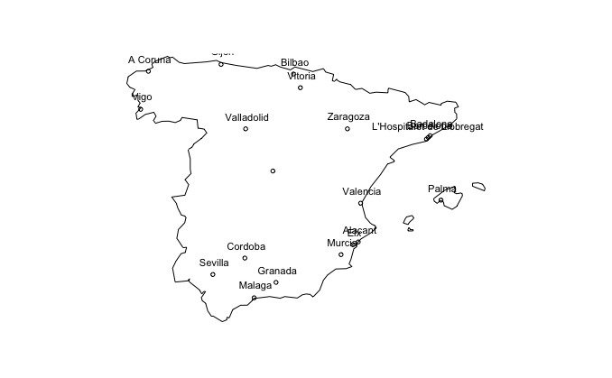

```r
s2 <- subset(spain, pop > 214000)
#s2
map("world", "Spain")
map.cities(x = world.cities, country = "Spain", minpop = 214000, label = TRUE)
```

Now instead of using `map.cities`, create a new dataframe `myCities` with only the latitude and longitude of the cities you chose above. You are going to need to get this information directly from the `world.cities` dataset.

```r
myCities <- data.frame( s2$lat, s2$long)
myCities
```

| s2.lat | s2.long |
| --- | --- |
| 43.33 | -8.42 |
| 38.35 | -0.48 |
| 41.45 | 2.24 |
| 41.40 | 2.17 |
| 43.25 | -2.93 |
| 37.88 | -4.77 |
| 38.27 | -0.68 |
| 43.53 | -5.67 |
| 37.17 | -3.59 |
| 41.35 | 2.10 |

[output cut: 10 more lines]

Use the geosphere package to calculate the distances between each pair of cities (use the `distm` function). You will need to add row and column names to the result of `distm`.

```r
library(geosphere)
#distance matrix
distances <- distm(myCities, myCities, fun = distHaversine)
distances = distances/1000
distances = data.frame(distances, row.names = s2$name)
colnames(distances) <- rownames(distances)
distances
```

|  | A Coruna | Alacant | Badalona | Barcelona | Bilbao | Cordoba | Elx | Gijon | Granada | L'Hospitalet de Llobregat | Madrid | Malaga | Murcia | Palma | Sevilla | Valencia | Valladolid | Vigo | Vitoria | Zaragoza |
| --- | --- | --- | --- | --- | --- | --- | --- | --- | --- | --- | --- | --- | --- | --- | --- | --- | --- | --- | --- | --- |
| A Coruna | 0.0000 | 1042.21693 | 1204.87328 | 1198.178668 | 611.20820 | 726.7603 | 1028.18797 | 306.9248 | 868.2624 | 1191.523179 | 615.3136 | 855.9813 | 1005.14137 | 1301.0693 | 708.9588 | 990.6269 | 449.8016 | 126.3791 | 642.29081 | 858.6810 |
| Alacant | 1042.2169 | 0.00000 | 459.04043 | 449.726846 | 609.59560 | 480.4108 | 23.97878 | 815.5456 | 370.2507 | 440.424132 | 426.9641 | 474.5736 | 83.25712 | 373.9473 | 621.2878 | 126.1857 | 599.5769 | 1011.6458 | 556.91268 | 370.1519 |
| Badalona | 1204.8733 | 459.04043 | 0.00000 | 9.573670 | 609.38229 | 875.5607 | 480.54364 | 910.3984 | 804.9634 | 19.147489 | 672.1916 | 909.1142 | 538.41358 | 214.0130 | 1019.8058 | 365.7672 | 777.3284 | 1221.9397 | 568.34975 | 349.1403 |
| Barcelona | 1198.1787 | 449.72685 | 9.57367 | 0.000000 | 603.90274 | 866.0946 | 471.18166 | 904.3033 | 795.3906 | 9.573819 | 663.5779 | 899.5406 | 528.99840 | 210.4309 | 1010.3601 | 356.1962 | 769.7201 | 1214.5695 | 562.43130 | 341.7722 |
| Bilbao | 611.2082 | 609.59560 | 609.38229 | 603.902740 | 0.00000 | 630.6020 | 608.04379 | 306.5947 | 679.7049 | 598.526212 | 326.2688 | 744.1206 | 619.55809 | 743.9942 | 732.5986 | 505.8639 | 268.6569 | 653.4508 | 53.06309 | 288.5406 |
| Cordoba | 726.7603 | 480.41078 | 875.56065 | 866.094622 | 630.60203 | 0.0000 | 457.35639 | 634.3002 | 153.1929 | 856.630904 | 305.6676 | 134.4830 | 405.35537 | 847.1079 | 144.8210 | 519.0158 | 418.2429 | 649.9762 | 599.51585 | 601.8173 |
| Elx | 1028.1880 | 23.97878 | 480.54364 | 471.181656 | 608.04379 | 457.3564 | 0.00000 | 806.3187 | 346.2763 | 461.828079 | 413.4667 | 450.5963 | 59.59270 | 397.9251 | 597.8572 | 138.5053 | 587.7590 | 995.3789 | 555.66666 | 376.9499 |
| Gijon | 306.9248 | 815.54559 | 910.39839 | 904.303347 | 306.59466 | 634.3002 | 806.31872 | 0.0000 | 742.6576 | 898.268891 | 408.2264 | 767.8437 | 797.23287 | 1025.5027 | 679.7373 | 740.2819 | 232.7118 | 368.0351 | 342.38387 | 571.6358 |
| Granada | 868.2624 | 370.25073 | 804.96341 | 795.390601 | 679.70493 | 153.1929 | 346.27627 | 742.6576 | 0.0000 | 785.817654 | 361.3012 | 105.0427 | 288.28280 | 744.1899 | 267.2740 | 439.2294 | 513.5955 | 798.1433 | 639.59649 | 581.9146 |
| L'Hospitalet de Llobregat | 1191.5232 | 440.42413 | 19.14749 | 9.573819 | 598.52621 | 856.6309 | 461.82808 | 898.2689 | 785.8177 | 0.000000 | 654.9909 | 889.9668 | 519.58875 | 207.2288 | 1000.9169 | 346.6252 | 762.1561 | 1207.2301 | 556.61465 | 334.5159 |

[output cut: 10 more lines]

```r
#not sure how to add header names.
```

Use this data frame to perform a PCoA, plot the results and compare to your original graph of the cities.

```r
library(ape)
newdist <- distances/1000
#newdist
pcoaRes <- pcoa(newdist)
pcoaRes
```

```
$correction
[1] "none" "1"

$note
[1] "No correction was applied to the negative eigenvalues"

$values
     Eigenvalues  Relative_eig Rel_corr_eig Broken_stick Cum_corr_eig Cumul_br_stick
1   2.768268e+00  7.036904e-01 7.013095e-01  0.194172671    0.7013095      0.1941727
2   1.166529e+00  2.965302e-01 2.956382e-01  0.138617115    0.9969476      0.3327898
3   3.086118e-04  7.844874e-05 2.706412e-04  0.110839338    0.9972183      0.4436291
4   4.894899e-07  1.244277e-07 1.926034e-04  0.092320819    0.9974109      0.5359499
5   2.136263e-07  5.430355e-08 1.925335e-04  0.078431930    0.9976034      0.6143819
6   0.000000e+00  0.000000e+00 1.924794e-04  0.067320819    0.9977959      0.6817027
7   0.000000e+00  0.000000e+00 1.924794e-04  0.058061560    0.9979884      0.7397643
8   0.000000e+00  0.000000e+00 1.924794e-04  0.050125052    0.9981809      0.7898893
9   0.000000e+00  0.000000e+00 1.924794e-04  0.043180608    0.9983733      0.8330699
10  0.000000e+00  0.000000e+00 1.924794e-04  0.037007768    0.9985658      0.8700777
11  0.000000e+00  0.000000e+00 1.924794e-04  0.031452212    0.9987583      0.9015299
12  0.000000e+00  0.000000e+00 1.924794e-04  0.026401707    0.9989508      0.9279316
13  0.000000e+00  0.000000e+00 1.924794e-04  0.021772078    0.9991433      0.9497037
14  0.000000e+00  0.000000e+00 1.924794e-04  0.017498574    0.9993357      0.9672023
15  0.000000e+00  0.000000e+00 1.924794e-04  0.013530320    0.9995282      0.9807326
16  0.000000e+00  0.000000e+00 1.924794e-04  0.009826616    0.9997207      0.9905592
17  0.000000e+00  0.000000e+00 1.924612e-04  0.006354394    0.9999132      0.9969136
18 -7.203328e-08 -1.831077e-08 8.684531e-05  0.003086420    1.0000000      1.0000000
19 -4.170823e-04 -1.060218e-04 0.000000e+00  0.000000000    1.0000000      1.0000000
20 -7.599796e-04 -1.931859e-04 0.000000e+00  0.000000000    1.0000000      1.0000000

$vectors
                               Axis.1       Axis.2        Axis.3        Axis.4
A Coruna                   0.69897806 -0.241115906  0.0058019809  1.071797e-04
Alacant                   -0.25273379  0.183647036 -0.0016064617  2.905459e-05
Badalona                  -0.50527207 -0.199896730  0.0035368593  1.382970e-04
Barcelona                 -0.49832373 -0.193310127  0.0031536171  1.218231e-04
Bilbao                     0.09247584 -0.319032267  0.0003808421 -7.586187e-05
Cordoba                    0.21358713  0.299924182 -0.0018941954 -4.867111e-05
Elx                       -0.23188378  0.195499475 -0.0016248907  5.612543e-05
Gijon                      0.39891621 -0.306788231  0.0024282507 -2.093838e-04
Granada                    0.07272701  0.360415479  0.0020455787  1.835692e-04
```

[output cut: 23 more lines]

```
Malaga                     6.802351e-05
Murcia                    -7.582254e-05
Palma                     -7.887504e-07
Sevilla                   -6.891595e-05
Valencia                   5.924071e-05
Valladolid                 9.255880e-05
Vigo                      -2.426713e-04
Vitoria                   -1.212179e-04
Zaragoza                  -1.121335e-05

$trace
[1] 3.933929

attr(,"class")
[1] "pcoa"
```

```r
library(plotly)
pcoaResDf <- data.frame(pcoaRes$vectors)
pcoaResDf
```

|  | Axis.1 | Axis.2 | Axis.3 | Axis.4 | Axis.5 |
| --- | --- | --- | --- | --- | --- |
| A Coruna | 0.69897806 | -0.241115906 | 0.0058019809 | 1.071797e-04 | 1.665562e-04 |
| Alacant | -0.25273379 | 0.183647036 | -0.0016064617 | 2.905459e-05 | -7.923707e-05 |
| Badalona | -0.50527207 | -0.199896730 | 0.0035368593 | 1.382970e-04 | 3.334440e-05 |
| Barcelona | -0.49832373 | -0.193310127 | 0.0031536171 | 1.218231e-04 | 3.610706e-05 |
| Bilbao | 0.09247584 | -0.319032267 | 0.0003808421 | -7.586187e-05 | -1.760217e-04 |
| Cordoba | 0.21358713 | 0.299924182 | -0.0018941954 | -4.867111e-05 | 4.658587e-05 |
| Elx | -0.23188378 | 0.195499475 | -0.0016248907 | 5.612543e-05 | -7.360542e-05 |
| Gijon | 0.39891621 | -0.306788231 | 0.0024282507 | -2.093838e-04 | 1.303204e-04 |
| Granada | 0.07272701 | 0.360415479 | 0.0020455787 | 1.835692e-04 | 4.791458e-05 |
| L'Hospitalet de Llobregat | -0.49137531 | -0.186723389 | 0.0027790519 | 1.062107e-04 | 3.873336e-05 |

[output cut: 10 more lines]

```r
#still working on it
```

```r
p <- plot_ly(pcoaResDf, x = ~Axis.1 , y = ~Axis.2, text = rownames(pcoaResDf), type = 'scatter',
             mode = "markers", marker = list(size = 11)) # width = 800, height = 600) #create a df from our PCoA results, get the vectors part of it and throw into pcoaResDf. The x and y should be columns of the dataframe. Text is the text shown with the points. type is scatter plot, mode could be line but we just want points because scatter plot

p <- layout(p, title = "PCoA from Spain City Distances",
       xaxis = list(title = "PC 1", autorange='reversed'), #list of parameters to x axis
       yaxis = list(title = "PC 2", autorange='reversed'))

p
```

[interactive chart not shown]